# netSEM Modeling of the Weathering Driven Degradation of Poly(ethylene-terephthalate) Films

Devin A. Gordon, Abdulkerim Gok, Laura S. Bruckman, Roger H. French

2026-02-24

## Data Description

The data set is a study of photolysis and hydrolysis of poly(ethylene-terephthalate) films that contain an ultraviolet stabilizer additive. In this work, polymeric samples were exposed to UV light and moisture according to ASTM G-154 Cycle 4 standard accelerated weathering conditions. Resulting optical chemical changes were determined through optical and infrared (IR) spectroscopy. *Time* is the main exogenous stressor variable and *YI* (yellowness index) is the endogenous response variable. The other columns in the data set (*AbsEdge*, *UVStabBleaching*, *Crystallization*, and *ChainScission*) are values extracted from optical and IR absorbance spectra as single metrics and used as intermediate unit level endogenous mechanistic variables in the netSEM analysis.

## Load data and run code to build netSEM

```r
## Load the PET data set
data(pet)
?pet

## Run netSEMp1 model
ans1 <- netSEMp1(pet, exogenous = "Time", endogenous = "YI")
## Plot the network model for principle 1
plot(ans1, cutoff = c(0.3,0.6,0.9))

## Run netSEMp2 model
ans2 <- netSEMp2(pet, exogenous = "Time", endogenous = "YI")
## Plot the network model for principle 2
plot(ans2, cutoff = c(0.3,0.6,0.9))
```

## Network diagram for data

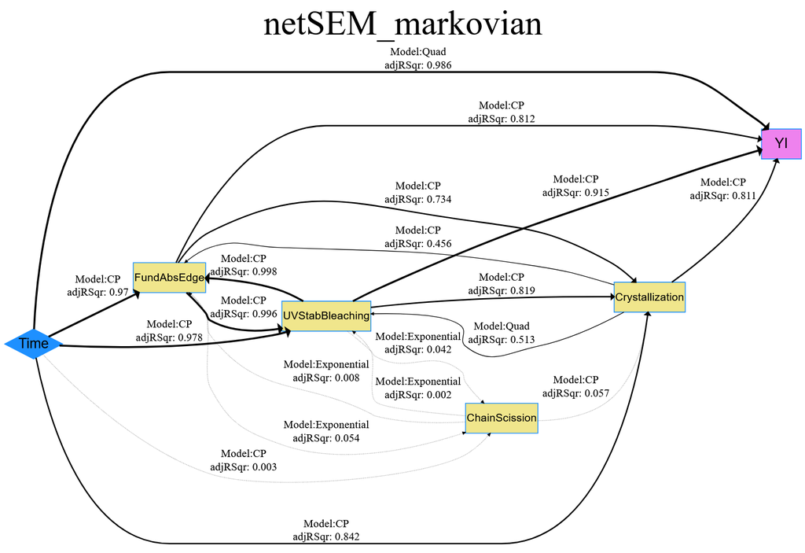

PET netSEMp1 model

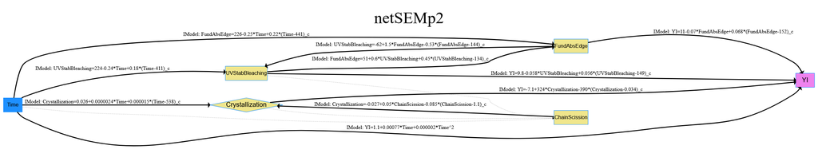

PET netSEMp2 model

## Discussion

The network diagram shows a strong quadratic relationship between Time and YI. This relationship is useful, as it gives an expected temporal evolution of the property of interest. To understand, which mechanisms contribute most to the yellowing of PET, one can examine the inner portion of the network diagram. Time shows strong change-point relationships with FundAbsEdge, UVStabBleaching, and Crystallization, all of which have relatively strong change-point relationships with YI. The pathway predict function will help find which pathway describes the mechanistic relationship from Time to YI with lowest error.

```r
# Use pathwayRMSE to examine errors of network paths
pathwayRMSE(ans)
```

[output not shown]

## Reference

Gok, A., Ngendahimana, D.K., Fagerholm, C.L., French, R.H., Sun, J., Bruckman, L.S., 2017. Predictive models of poly(ethylene-terephthalate) film degradation under multi-factor accelerated weathering exposures. PLOS ONE 12. https://doi.org/10.1371/journal.pone.0177614

## Acknowledgment

The authors would like to acknowledge 3M Company for funding and support throughout this project.